# Linear regression

Maria Cuellar

# Example 1: Court caseload and waiting time

These are fictional courts. **x** is daily caseload; **y** is mean waiting time in minutes. Court 21 is deliberately unusual.

## 1. Explore the data

```r
library(tidyverse)
```

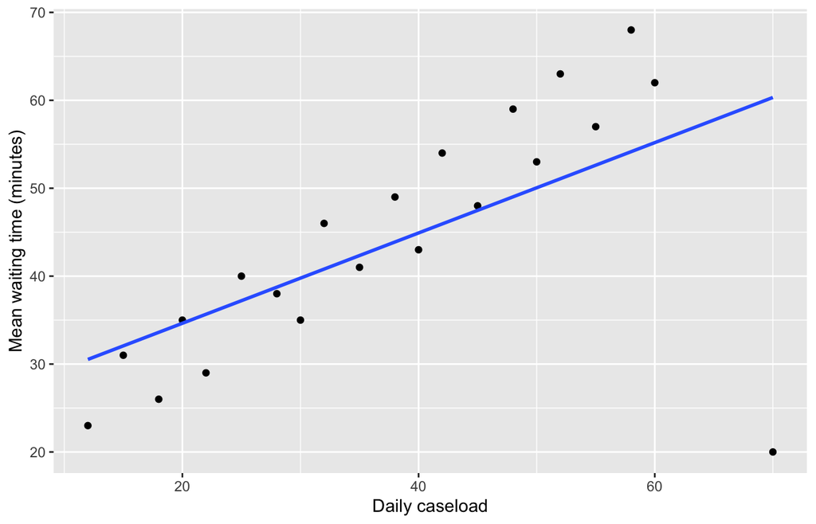

```r
courts <- data.frame(
  court_id = 1:21,
  caseload = c(12, 15, 18, 20, 22, 25, 28, 30, 32, 35,
               38, 40, 42, 45, 48, 50, 52, 55, 58, 60, 70),
  wait_minutes = c(23, 31, 26, 35, 29, 40, 38, 35, 46, 41,
                   49, 43, 54, 48, 59, 53, 63, 57, 68, 62, 20)
)

courts %>%
  ggplot(aes(x = caseload, y = wait_minutes)) +
  geom_point() +
  geom_smooth(method = "lm", se = FALSE) +
  labs(x = "Daily caseload", y = "Mean waiting time (minutes)")
```

```r
cor(courts$caseload, courts$wait_minutes)
```

```
## [1] 0.601766
```

Describe direction, strength, shape, and unusual points. Correlation summarizes a **linear** association and is sensitive to outliers.

## 2. Fit the full model

```r
model_full <- lm(wait_minutes ~ caseload, data = courts)
summary(model_full)
```

```
##
## Call:
## lm(formula = wait_minutes ~ caseload, data = courts)
##
## Residuals:
##     Min      1Q  Median      3Q     Max
## -40.321  -1.910   0.521   5.199  13.843
##
## Coefficients:
##             Estimate Std. Error t value Pr(>|t|)
## (Intercept)  24.3626     6.4187   3.796  0.00122 **
## caseload      0.5137     0.1564   3.284  0.00390 **
## ---
## Signif. codes:  0 '***' 0.001 '**' 0.01 '*' 0.05 '.' 0.1 ' ' 1
##
## Residual standard error: 11.35 on 19 degrees of freedom
## Multiple R-squared:  0.3621, Adjusted R-squared:  0.3285
## F-statistic: 10.79 on 1 and 19 DF,  p-value: 0.003901
```

In the coefficient table, use the `caseload` row for the slope and its p-value.

## 3. Check influence and refit if justified

```r
cook <- cooks.distance(model_full)
data.frame(court_id = courts$court_id,
           cooks_distance = round(cook, 3))
```

```
##    court_id cooks_distance
## 1         1          0.056
## 2         2          0.001
## 3         3          0.036
## 4         4          0.000
## 5         5          0.020
## 6         6          0.003
## 7         7          0.000
## 8         8          0.006
## 9         9          0.006
## 10       10          0.000
## 11       11          0.005
## 12       12          0.001
## 13       13          0.014
## 14       14          0.000
## 15       15          0.030
## 16       16          0.003
## 17       17          0.056
## 18       18          0.010
## 19       19          0.121
## 20       20          0.034
## 21       21          2.687
```

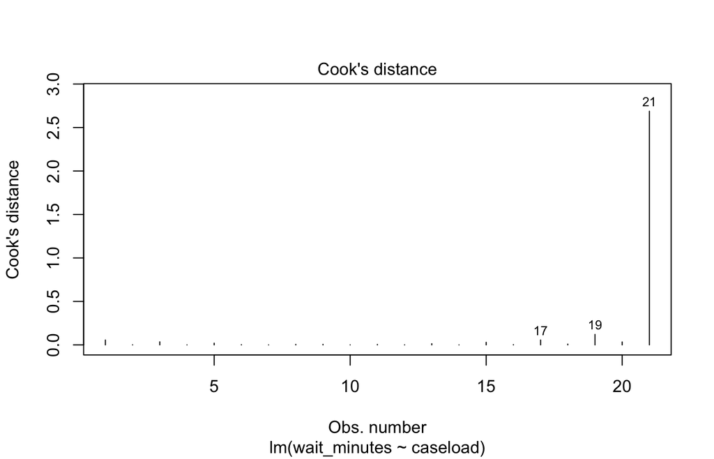

```r
plot(model_full, which = 4)
```

Court 21 has a large Cook’s distance. We omit it **only for a sensitivity analysis** and retain the original model.

```r
courts_without_21 <- filter(courts, court_id != 21)
model_without_21 <- lm(wait_minutes ~ caseload, data = courts_without_21)
summary(model_without_21)
```

```
##
## Call:
## lm(formula = wait_minutes ~ caseload, data = courts_without_21)
##
## Residuals:
##     Min      1Q  Median      3Q     Max
## -5.1461 -3.6994 -0.8669  4.1507  4.7864
##
## Coefficients:
##             Estimate Std. Error t value Pr(>|t|)
## (Intercept) 14.58769    2.46027   5.929 1.30e-05 ***
## caseload     0.83896    0.06304  13.309 9.37e-11 ***
## ---
## Signif. codes:  0 '***' 0.001 '**' 0.01 '*' 0.05 '.' 0.1 ' ' 1
##
## Residual standard error: 4.077 on 18 degrees of freedom
## Multiple R-squared:  0.9078, Adjusted R-squared:  0.9026
## F-statistic: 177.1 on 1 and 18 DF,  p-value: 9.369e-11
```

When an exercise specifies a Cook’s distance cutoff (such as 0.05), this is the filtering pattern. It assumes the fitted model used every row in the same order; check for missing values and inspect the flagged rows before excluding them.

```r
model <- lm(y ~ x, data = dat)
dat_nooutliers <- dat %>% filter(cooks.distance(model) <= 0.05)
model_nooutliers <- lm(y ~ x, data = dat_nooutliers)
```

## 4. Compare both models

```r
# Correlation can change when an influential point is removed.
cor(courts$caseload, courts$wait_minutes)
```

```
## [1] 0.601766
```

```r
cor(courts_without_21$caseload, courts_without_21$wait_minutes)
```

```
## [1] 0.9527607
```

```r
# Compare the slope, its p-value, and R-squared in each summary.
summary(model_full)
```

```
##
## Call:
## lm(formula = wait_minutes ~ caseload, data = courts)
##
## Residuals:
##     Min      1Q  Median      3Q     Max
## -40.321  -1.910   0.521   5.199  13.843
##
## Coefficients:
##             Estimate Std. Error t value Pr(>|t|)
## (Intercept)  24.3626     6.4187   3.796  0.00122 **
## caseload      0.5137     0.1564   3.284  0.00390 **
## ---
## Signif. codes:  0 '***' 0.001 '**' 0.01 '*' 0.05 '.' 0.1 ' ' 1
##
## Residual standard error: 11.35 on 19 degrees of freedom
## Multiple R-squared:  0.3621, Adjusted R-squared:  0.3285
## F-statistic: 10.79 on 1 and 19 DF,  p-value: 0.003901
```

```r
summary(model_without_21)
```

```
##
## Call:
## lm(formula = wait_minutes ~ caseload, data = courts_without_21)
##
## Residuals:
##     Min      1Q  Median      3Q     Max
## -5.1461 -3.6994 -0.8669  4.1507  4.7864
##
## Coefficients:
##             Estimate Std. Error t value Pr(>|t|)
## (Intercept) 14.58769    2.46027   5.929 1.30e-05 ***
## caseload     0.83896    0.06304  13.309 9.37e-11 ***
## ---
## Signif. codes:  0 '***' 0.001 '**' 0.01 '*' 0.05 '.' 0.1 ' ' 1
##
## Residual standard error: 4.077 on 18 degrees of freedom
## Multiple R-squared:  0.9078, Adjusted R-squared:  0.9026
## F-statistic: 177.1 on 1 and 18 DF,  p-value: 9.369e-11
```

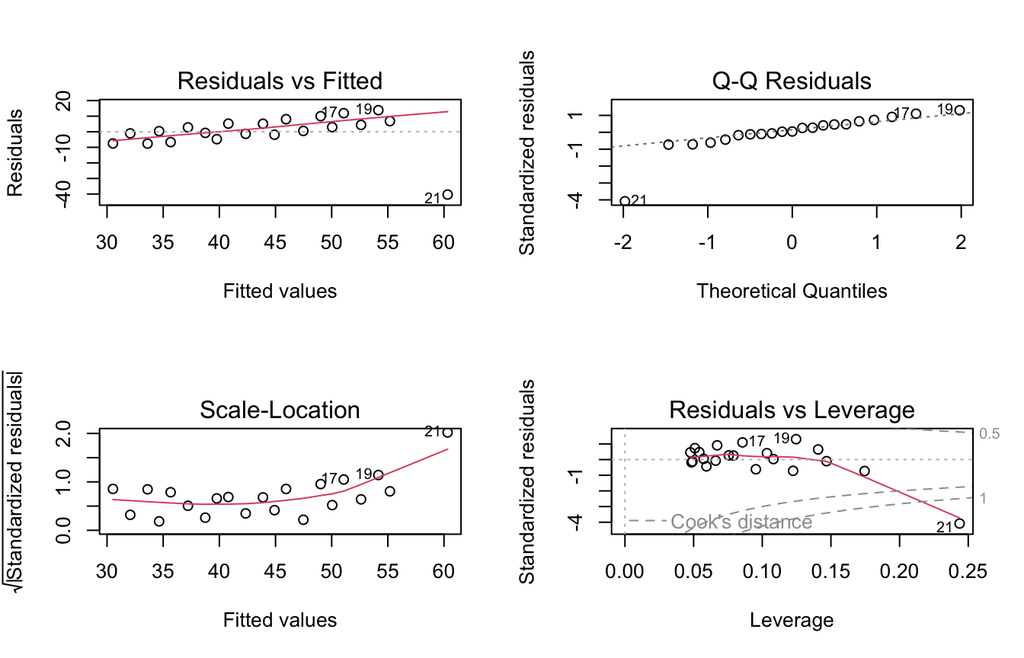

```r
# R's four standard diagnostic plots for each model.
par(mfrow = c(2, 2))
plot(model_full)
```

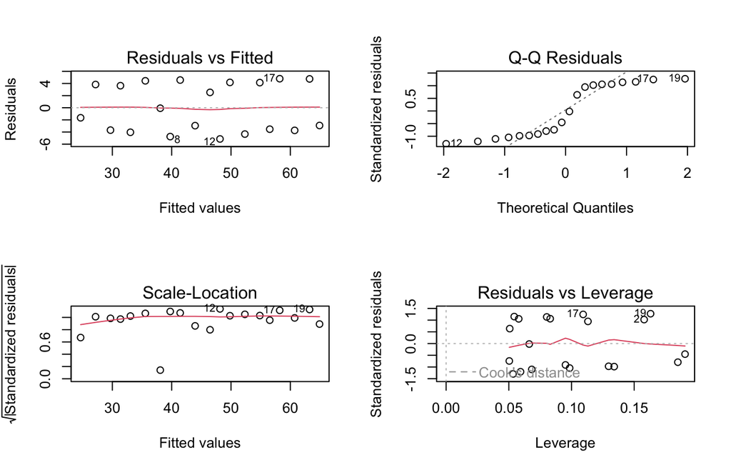

```r
plot(model_without_21)
```

```r
par(mfrow = c(1, 1))
```

| Check | What to look for |
| --- | --- |
| Linearity | Roughly straight scatterplot; no clear curve in residuals |
| Constant variance | Similar residual spread across fitted values |
| Normality | Q-Q points roughly follow the line |
| Independence | Does the study design make observations independent? |

Be reasonable with real data: small departures are common. The residuals vs leverage plot also helps identify influential points. Report if the conclusion changes between models.

## 5. Interpret

Use this sentence: **For one additional case per day, predicted mean waiting time changes by [slope] minutes, on average.** Then state whether the slope is statistically significant at 0.05, give its p-value, and describe association strength using correlation or R-squared. Read these from `summary(model_full)` and `summary(model_without_21)`.

Association does not establish that adding cases *causes* waiting time to change.

# Example 2: Try the workflow

Each row is a fictional neighborhood. **x** is weekly recreation program hours; **y** is reported incidents per 1,000 residents.

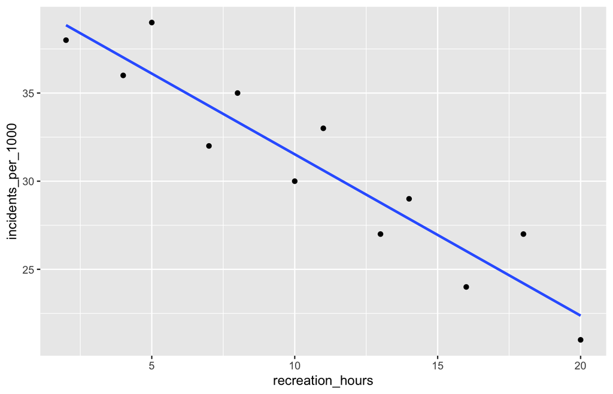

```r
neighborhoods <- data.frame(
  recreation_hours = c(2, 4, 5, 7, 8, 10, 11, 13, 14, 16, 18, 20),
  incidents_per_1000 = c(38, 36, 39, 32, 35, 30, 33, 27, 29, 24, 27, 21)
)
neighborhoods %>%
  ggplot(aes(x = recreation_hours, y = incidents_per_1000)) +
  geom_point() +
  geom_smooth(method = "lm", se = FALSE)
```

```r
cor(neighborhoods$recreation_hours, neighborhoods$incidents_per_1000)
```

```
## [1] -0.9334958
```

```r
model2 <- lm(incidents_per_1000 ~ recreation_hours, data = neighborhoods)
summary(model2)
```

```
##
## Call:
## lm(formula = incidents_per_1000 ~ recreation_hours, data = neighborhoods)
##
## Residuals:
##     Min      1Q  Median      3Q     Max
## -2.2732 -1.5904 -0.9349  1.8288  2.8959
##
## Coefficients:
##                  Estimate Std. Error t value Pr(>|t|)
## (Intercept)       40.6812     1.3329  30.522 3.34e-11 ***
## recreation_hours  -0.9154     0.1112  -8.232 9.16e-06 ***
## ---
## Signif. codes:  0 '***' 0.001 '**' 0.01 '*' 0.05 '.' 0.1 ' ' 1
##
## Residual standard error: 2.106 on 10 degrees of freedom
## Multiple R-squared:  0.8714, Adjusted R-squared:  0.8586
## F-statistic: 67.77 on 1 and 10 DF,  p-value: 9.157e-06
```

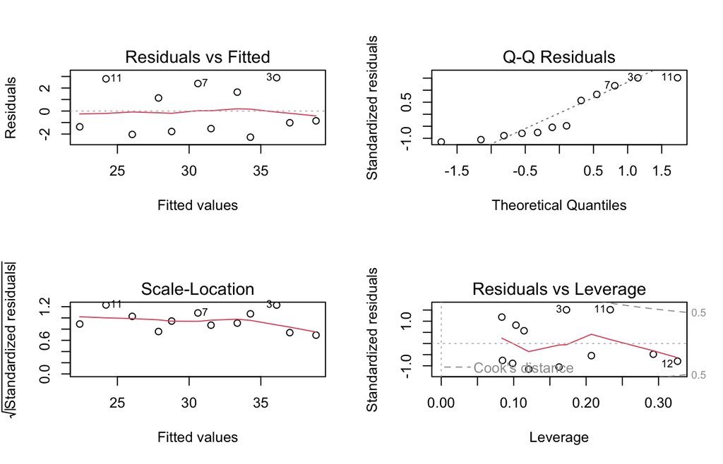

```r
par(mfrow = c(2, 2))
plot(model2)
```

```r
par(mfrow = c(1, 1))
```

Describe the slope in **incidents per 1,000 residents per additional program hour**. Give the p-value and say whether the association is strong. Can you interpret it as causal? Why or why not?